# Part II - (Sources de revenue VS Remboursement des prêts)

## by (OUEDRAOGO Salam)

## Investigation Overview

Dans cette présentation, je vais montrer à quel points les sources de revenues peuvent être capitale pour determiner la solvabilité d'un emprunteur. Nous allons proceder en trois grandes étapes :

- Visualiser les sources de revenues et les proportions des prêts soldés et non soldées;
- Visualiser la rélation entre les sources de revenues et les statuts des prêts ainsi que d'autre variable;
- visualiser la rélation entre le sources de revenues, la durée du prêt et les status des prêts.

## Dataset Overview

- Prosper est une société basée à San Francisco, en Californie, dans le secteur des prêts à des particuliers en ligne.
- Cet ensemble de données est extrais des données de Prosper.
- Il est constitué d’environ 113,937 prêts et 81 variables, y compris le montant du prêt, le taux de l'emprunteur (ou taux d'intérêt), le statut actuel du prêt, le revenu de l'emprunteur, et bien d'autres.
- Les données sont téléchargeable en utilisant le [lien](https://s3.amazonaws.com/udacity-hosted-downloads/ud651/prosperLoanData.csv).
- La [documentation](https://docs.google.com/spreadsheets/d/1gDyi_L4UvIrLTEC6Wri5nbaMmkGmLQBk-Yx3z0XDEtI/edit#gid=0) du dataset permet de mieux comprendre chacun de ses variables.

L'analyse des plages des sources de revenues nous montre que :

> - 28.25% des emprunteurs ont une source de revenues compris dans la plage 25,000-49,999 dollars;
> - 27.25% ont une source de revenus dans la plage 50,000-74,999 dollars;
> - 14.85% et 15.22% ont respectivement leurs sources de revenus dans 75,000-99,999 dollars et 100,000+ dollars.

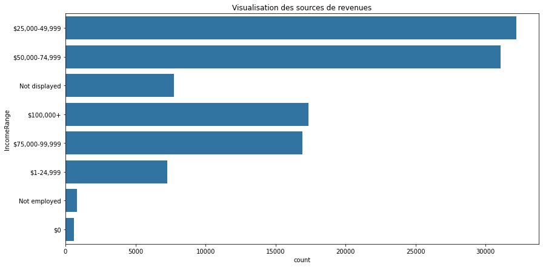

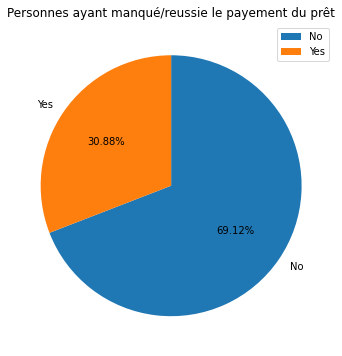

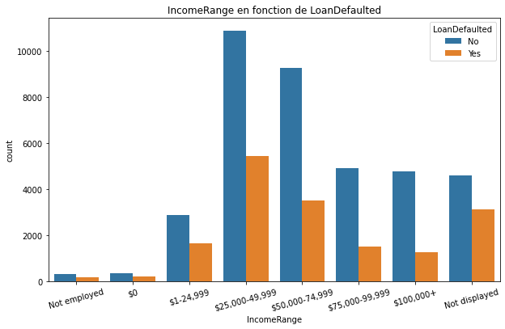

Les emprunteurs ayant une source de revenue au moins égale à 100000 dollars ont beaucoup plus de chance d'avoir une importante somme d'argent de prêts. La somme maximale qu'ils peuvent avoir est de 35 000 dollars ce qui est nettement supérieur à ceux qui ont une source de revenues inférieur 10000 qui ont une somme maximale de 25 000. En conclusion Plus les sources de revenues sont élevées plus ont à beaucoup de chance d'avoir un gros montant de prêts.

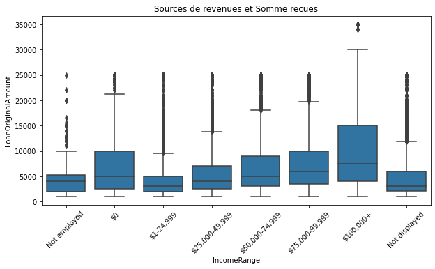

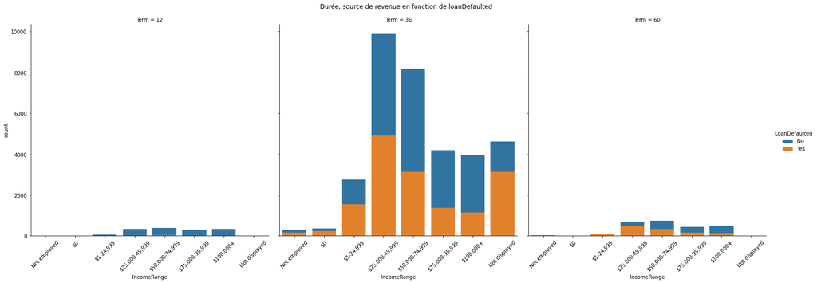